# Forecasting Methods Project

## 2. Data Exploration (EDA) and Stationarity Analysis

### 2.1 Training and Test Data Split

To evaluate our forecasting models rigorously, the dataset was split into training and test sets. before 2019, ensuring that the model is fitted only on historical data prior to the evaluation period. The test set consists in the 12 months of 2019, which will serve as our out‑of‑sample window for assessing predictive performance. The year of 2020 was intentionally excluded from the analysis, as it represents an exceptionally atypical period due to the economic disruptions caused by the COVID‑19 pandemic. Including such an abnormal year would distort the evaluation and prevent us from obtaining forecasts that reflect a more typical economic environment.

```r
# Split into Training Data (All data prior to 2019)
train_data <- unemployment_ts %>%
  filter(year(observation_date) < 2019)

# Split into Test Data (Exactly the year 2019)
test_data <- unemployment_ts %>%
  filter(year(observation_date) > 2018 & year(observation_date) < 2020)
```

### 2.2 Time Series Visualization

A visual inspection of the training series is conducted to analyze its characteristics, such as long-term trends, cyclical movements, and seasonal patterns.

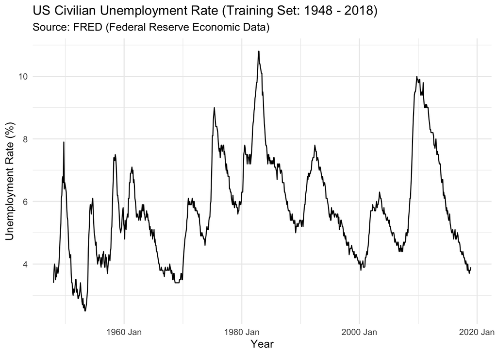

```r
# Visualizing the training dataset
train_data %>%
  autoplot(UNRATE) +
  labs(title = "US Civilian Unemployment Rate (Training Set: 1948 - 2018)",
       subtitle = "Source: FRED (Federal Reserve Economic Data)",
       y = "Unemployment Rate (%)",
       x = "Year") +
  theme_minimal()
```

#### Explanation of Plot:

The time series plot reveals that the US Civilian Unemployment Rate fluctuates between approximately 2% and 11%. The series displays prominent cyclicality, with sharp, rapid increases probabily during economic recessions, followed by long, slow recovery periods. The lack of a mean reverse behaviour strongly suggest that the series is non-stationary, indicating the possible need of a mathematical differentiating before ARIMA modeling.

### 2.3 Stationarity Testing on the Raw Series

To check the non-stationary behavior, we will examine the ACF/PACF plots and apply the Augmented Dickey-Fuller (ADF) unit root test.

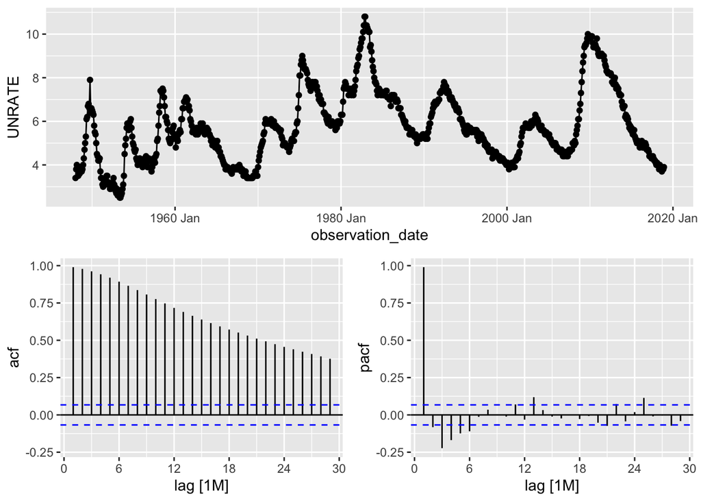

```r
# Visualizing ACF and PACF plots for the raw series
train_data %>%
  gg_tsdisplay(UNRATE, plot_type = 'partial')
```

```r
# ADF test on the raw series: Type = "drift" (allowing for non-zero mean)
adf_drift <- ur.df(train_data$UNRATE,
                   type = "drift",
                   lags = 24)
summary(adf_drift)
```

```
##
## ###############################################
## # Augmented Dickey-Fuller Test Unit Root Test #
## ###############################################
##
## Test regression drift
##
##
## Call:
## lm(formula = z.diff ~ z.lag.1 + 1 + z.diff.lag)
##
## Residuals:
##      Min       1Q   Median       3Q      Max
## -0.64654 -0.10799 -0.01018  0.10662  0.74969
##
## Coefficients:
##                Estimate Std. Error t value Pr(>|t|)
## (Intercept)   0.0656789  0.0261091   2.516 0.012079 *
## z.lag.1      -0.0114537  0.0043775  -2.617 0.009050 **
## z.diff.lag1   0.0667003  0.0346836   1.923 0.054821 .
## z.diff.lag2   0.1834072  0.0347337   5.280 1.66e-07 ***
## z.diff.lag3   0.1236303  0.0337604   3.662 0.000267 ***
## z.diff.lag4   0.1351871  0.0333644   4.052 5.58e-05 ***
## z.diff.lag5   0.1169735  0.0336019   3.481 0.000526 ***
## z.diff.lag6   0.0346697  0.0337673   1.027 0.304861
## z.diff.lag7  -0.0001231  0.0337577  -0.004 0.997092
## z.diff.lag8   0.0326537  0.0337599   0.967 0.333720
## z.diff.lag9   0.0116947  0.0336672   0.347 0.728412
## z.diff.lag10 -0.0713796  0.0336503  -2.121 0.034210 *
## z.diff.lag11  0.0200458  0.0337439   0.594 0.552642
## z.diff.lag12 -0.1693765  0.0336963  -5.027 6.16e-07 ***
## z.diff.lag13 -0.0219247  0.0336826  -0.651 0.515284
## z.diff.lag14 -0.0140954  0.0336734  -0.419 0.675628
## z.diff.lag15  0.0281747  0.0334513   0.842 0.399893
## z.diff.lag16  0.0192486  0.0334627   0.575 0.565299
## z.diff.lag17  0.0114779  0.0334717   0.343 0.731754
## z.diff.lag18  0.0023981  0.0334241   0.072 0.942820
## z.diff.lag19  0.0822331  0.0334164   2.461 0.014070 *
## z.diff.lag20  0.0757518  0.0332135   2.281 0.022825 *
## z.diff.lag21  0.0175766  0.0330387   0.532 0.594874
## z.diff.lag22 -0.0231406  0.0327495  -0.707 0.480024
## z.diff.lag23 -0.0300182  0.0320976  -0.935 0.349958
## z.diff.lag24 -0.1456508  0.0320038  -4.551 6.17e-06 ***
## ---
## Signif. codes:  0 '***' 0.001 '**' 0.01 '*' 0.05 '.' 0.1 ' ' 1
##
## Residual standard error: 0.1751 on 801 degrees of freedom
## Multiple R-squared:  0.2146, Adjusted R-squared:  0.1901
## F-statistic: 8.754 on 25 and 801 DF,  p-value: < 2.2e-16
##
##
## Value of test-statistic is: -2.6165 3.4307
##
## Critical values for test statistics:
##       1pct  5pct 10pct
## tau2 -3.43 -2.86 -2.57
## phi1  6.43  4.59  3.78
```

#### Plot Interpretation:

The raw ACF and PACF plots show a pattern characteristic of a non-stationary time series. The ACF presents a slow linear decay. The PACF shows a single dominant spike and cuts off after, which represents a classic random walk behavior. The formal Augmented Dickey-Fuller test has a test statistic of `-2.62`, which fails to exceed the critical value of `-2.86` at the 5% significance level. Therefore, we fail to reject the null hypothesis of a unit root, proving that the original series is non-stationary.

### 2.4 Seasonal Differencing (D = 1)

Given the monthly frequency of the data, seasonal patterns might exist. We apply a seasonal difference of lag 12 to see if stationarity can be achieved.

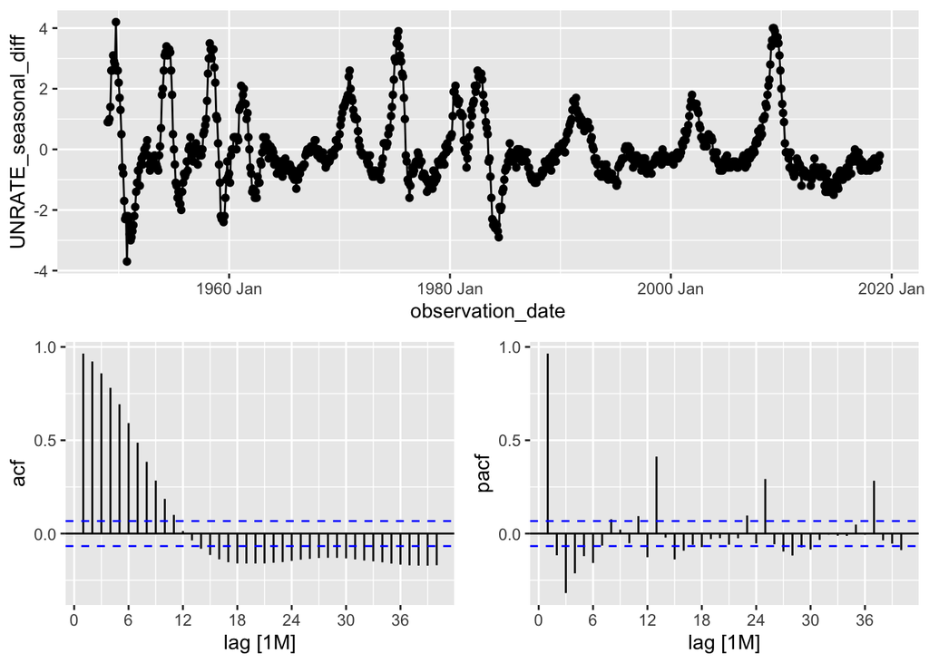

```r
# 1. Apply a seasonal difference (lag = 12 for monthly data)
diff_sazonal_data <- train_data %>%
  mutate(UNRATE_seasonal_diff = difference(UNRATE, lag = 12))

# 2. Plot ACF and PACF of the seasonally-differenced series
diff_sazonal_data %>%
  gg_tsdisplay(UNRATE_seasonal_diff, plot_type = 'partial', lag_max = 40)
```

```r
# 3. ADF test on the seasonally-differenced column (omitting leading NAs)
adf_drift_diff <- ur.df(na.omit(diff_sazonal_data$UNRATE_seasonal_diff),
                         type = "drift",
                         lags = 12)
summary(adf_drift_diff)
```

```
##
## ###############################################
## # Augmented Dickey-Fuller Test Unit Root Test #
## ###############################################
##
## Test regression drift
##
##
## Call:
## lm(formula = z.diff ~ z.lag.1 + 1 + z.diff.lag)
##
## Residuals:
##      Min       1Q   Median       3Q      Max
## -0.80046 -0.14699  0.00028  0.15267  1.09341
##
## Coefficients:
##               Estimate Std. Error t value Pr(>|t|)
## (Intercept)  -0.002304   0.008448  -0.273 0.785132
## z.lag.1      -0.048168   0.010331  -4.662 3.65e-06 ***
## z.diff.lag1   0.070787   0.030439   2.326 0.020288 *
## z.diff.lag2   0.193952   0.030414   6.377 3.02e-10 ***
## z.diff.lag3   0.125490   0.030614   4.099 4.56e-05 ***
## z.diff.lag4   0.089615   0.030615   2.927 0.003516 **
## z.diff.lag5   0.092974   0.030764   3.022 0.002588 **
## z.diff.lag6   0.041136   0.030732   1.339 0.181096
## z.diff.lag7  -0.022751   0.030781  -0.739 0.460045
## z.diff.lag8   0.012808   0.030694   0.417 0.676597
## z.diff.lag9   0.039173   0.030510   1.284 0.199528
## z.diff.lag10  0.005809   0.030410   0.191 0.848556
## z.diff.lag11  0.106294   0.029995   3.544 0.000417 ***
## z.diff.lag12 -0.426457   0.030190 -14.126  < 2e-16 ***
## ---
## Signif. codes:  0 '***' 0.001 '**' 0.01 '*' 0.05 '.' 0.1 ' ' 1
##
## Residual standard error: 0.2428 on 813 degrees of freedom
## Multiple R-squared:  0.3856, Adjusted R-squared:  0.3758
## F-statistic: 39.26 on 13 and 813 DF,  p-value: < 2.2e-16
##
##
## Value of test-statistic is: -4.6624 10.8886
##
## Critical values for test statistics:
##       1pct  5pct 10pct
## tau2 -3.43 -2.86 -2.57
## phi1  6.43  4.59  3.78
```

#### Plot Interpretation:

After applying a seasonal difference ($D=1$, lag 12), the resulting series displays a more stable mean, and the ADF test statistic (`-4.66`) now rejects the null hypothesis of non-stationarity. However, the ACF plot decays slowly and shows significant, autocorrelations at early lags. This slow decay indicates that the series is still highly integrated and shows a strong regular trend. To continue our forecasting practice, an additional first-order difference ($d=1$) is necessary to solve this dependency.